# RNA-seq KO Analysis

# Adjustment for Technical Effects Via SVA (Version C)

As it appears that there may be technical variables at play I want to investigate if we can determine "non-biological" sources of variation present in the data which we can use to improve the DESEQ model. We can do this using a package called SVA (surrogate variable analysis) where we can compare a model that is aware of the biological difference of interest (in our case WT vs KO) vs one that is agnositc to the biological differences in the data. By adjusting for the variation of interest we can ideally identify technical factors that may be excerting unwanted influence on the data and our future differential expression analysis. Based on the PCA plot above I would expect that the primary surrogate variable will seperate the two KO clones and this will be something we may want to address.

```r
dex2 <- estimateSizeFactors(dex)
norm.cts <- counts(dex2, normalized=TRUE)
library(sva)
mm <- model.matrix(~ designation, colData(dex2))
mm0 <- model.matrix(~ 1, colData(dex2))
norm.cts <- norm.cts[rowSums(norm.cts) > 0,]

#at this point we determine the surrogate variables by using n.sv, in this example we are looking to see if there is at least 1 significant SV
fit <- svaseq(norm.cts, mod=mm, mod0=mm0, n.sv=1)
```

```
## Number of significant surrogate variables is:  1
## Iteration (out of 5 ):1  2  3  4  5
```

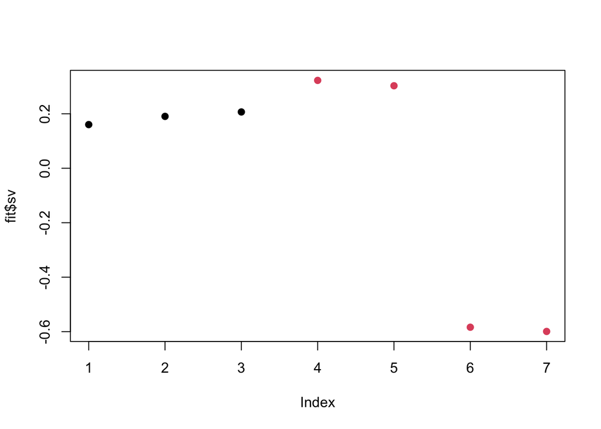

```r
#we can then look at the data in low dimension space to see if the significant SV seems important
plot(fit$sv,pch=19,col=dex2$designation)
```

If we focus on the Y axis, which is the variation from our primary surrogate variable SV1 (or in this case the only surrogate variable) it is clear that it seperates the two KO clones and this variation is something we may want to inform the DESEQ model of.

I can do this by adding in the SV1 information to the DESEQ object, and including it as a term in the design matrix

```r
dex2$SV1 = fit$sv[,1]
design(dex2)= ~ SV1 + designation
```

I can then run DESEQ2 with this updated object and design matrix and determine if there are differences between the results with the inclusion of this SV as a factor.

# Differential Expression Analysis with Inclusion of Information about Technical Variation

```r
desdex2<-DESeq2::DESeq(dex2)
res <- results(desdex2)
res <- res[order(res$padj),]
resdown<-res[na.omit(res$log2FoldChange < -1),]
resSig <- subset(resdown, padj < 0.0005)
summary(resSig)
```

```
##
## out of 576 with nonzero total read count
## adjusted p-value < 0.1
## LFC > 0 (up)       : 0, 0%
## LFC < 0 (down)     : 576, 100%
## outliers [1]       : 0, 0%
## low counts [2]     : 0, 0%
## (mean count < 7)
## [1] see 'cooksCutoff' argument of ?results
## [2] see 'independentFiltering' argument of ?results
```

Now just pvalue not LFC

```r
desdex2<-DESeq2::DESeq(dex2)
res <- results(desdex2)
res <- res[order(res$padj),]
resSig <- subset(res, padj < 0.0005)
summary(resSig)
```

```
##
## out of 1912 with nonzero total read count
## adjusted p-value < 0.1
## LFC > 0 (up)       : 1048, 55%
## LFC < 0 (down)     : 864, 45%
## outliers [1]       : 0, 0%
## low counts [2]     : 0, 0%
## (mean count < 7)
## [1] see 'cooksCutoff' argument of ?results
## [2] see 'independentFiltering' argument of ?results
```

# Plotting what it looks like after accounting for batch in the model (Version A)

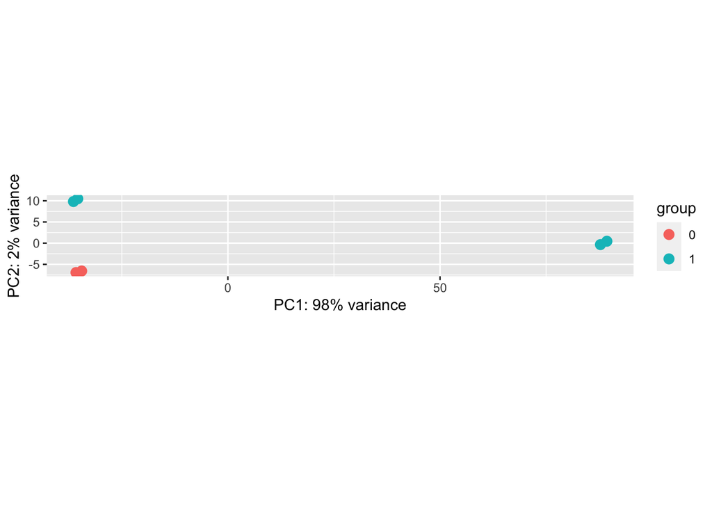

```r
vsd <- vst(dex)
plotPCA(vsd, "designation")
```

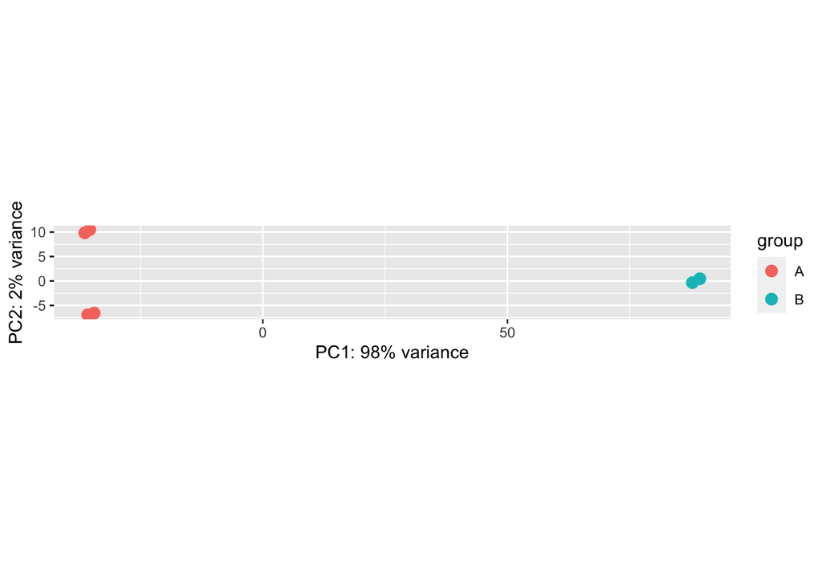

```r
plotPCA(vsd, "batch")
```

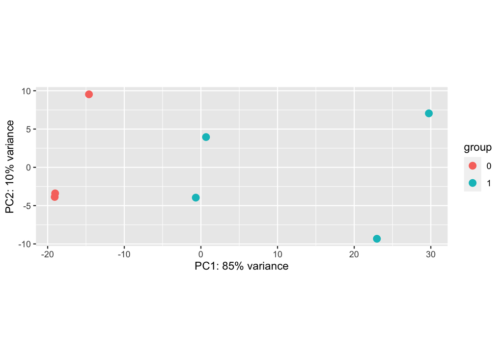

```r
assay(vsd) <- limma::removeBatchEffect(assay(vsd), vsd$batch)
plotPCA(vsd, "designation")
```

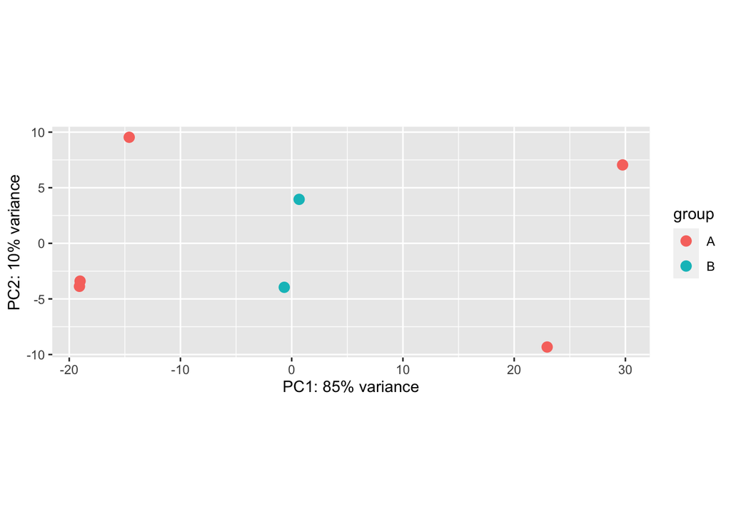

```r
plotPCA(vsd, "batch")
```

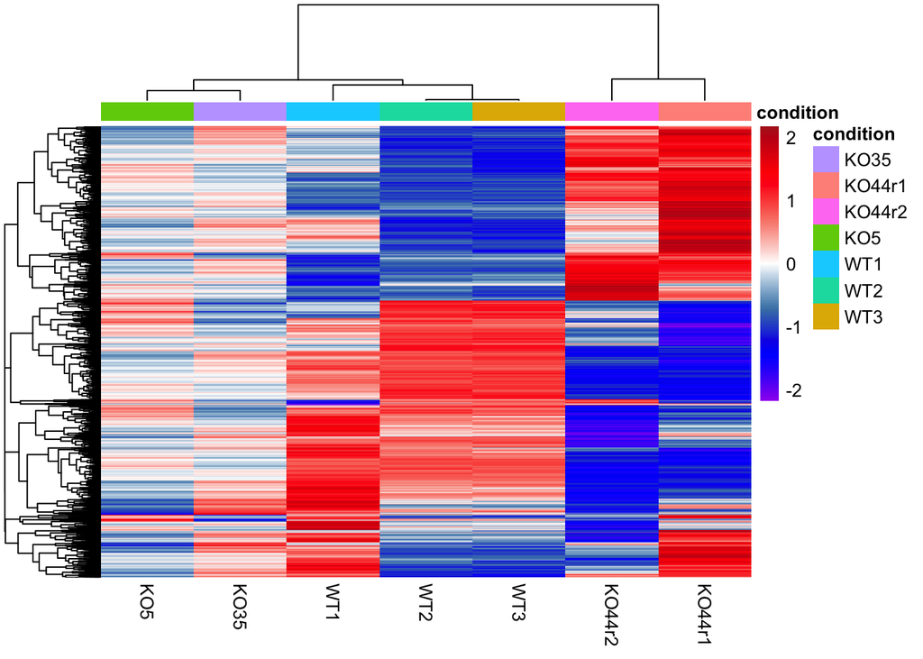

```r
logcts<- assay(vsd)

rv <- rowVars(logcts)
o <- order(rv, decreasing=TRUE)[1:3000]
qlfvals<- assay(vsd)

dists <- Dist(t(qlfvals[o,]), method = 'pearson')
cols <- colorRampPalette(c('purple',"blue","steelblue","white",'salmon',"red",'firebrick'))(255)
distmat <- as.matrix(dists)
df <- data.frame(condition=colnames(qlfvals[o,]),
                 row.names=colnames(distmat))
pheatmap(qlfvals[o,],scale = 'row',
         color = cols,
         #clustering_distance_rows= ,
         clustering_distance_cols=dists,
         annotation_col=df,
         show_rownames=FALSE, show_colnames=TRUE)
```

# Plotting what it looks like after accounting for batch in the model (Version C)

```r
vsd <- vst(dex)
```

```r
#remove for vizualization
svaBatchCor <- function(dat, mmi, mm0,n.sv=NULL){
  dat <- as.matrix(dat)
  Y <- t(dat)
  if(is.null(n.sv))   n.sv <- num.sv(dat,mmi,method="leek")
  o <- svaseq(dat,mmi,mm0,n.sv=n.sv)
  W <- o$sv
  alpha <- solve(t(W) %*% W) %*% t(W) %*% Y
  o$corrected <- t(Y - W %*% alpha)
  return(o)}

moda <- model.matrix(~ 1+designation, colData(vsd))
modb <- model.matrix(~ 1, colData(vsd))
correcteddata<- svaBatchCor(assay(vsd),moda,modb,1)
```

```
## Number of significant surrogate variables is:  1
## Iteration (out of 5 ):1  2  3  4  5
```

```r
setest<- SummarizedExperiment(correcteddata$corrected, colData = des)
correctedse<- DESeqTransform(setest)
rownames(correctedse) <- rownames(x.sub)
```

```r
#Looking at significant DEGs only
correctedse<- correctedse[rownames(correctedse) %in% rownames(resSig),]
correctedse
```

```
## class: DESeqTransform
## dim: 1912 7
## metadata(0):
## assays(1): ''
## rownames(1912): AAR2 AARS2 ... ZSWIM3 ZSWIM4
## rowData names(0):
## colnames(7): 1 2 ... 6 7
## colData names(3): sample designation batch
```

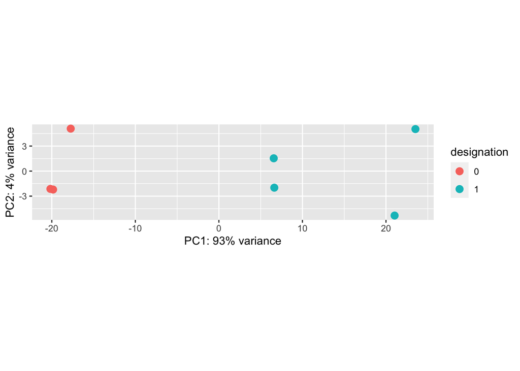

```r
#pdf(file = "SE14_KO_PCA_1SV.pdf",   # The directory you want to save the file in
#    width = 8, # The width of the plot in inches
#    height = 8) # The height of the plot in inches


pcaData <- plotPCA(correctedse,  intgroup=c("designation"), returnData=TRUE)
percentVar <- round(100 * attr(pcaData, "percentVar"))
ggplot(pcaData, aes(PC1, PC2, color=designation)) +
  geom_point(size=3) +
  xlab(paste0("PC1: ",percentVar[1],"% variance")) +
  ylab(paste0("PC2: ",percentVar[2],"% variance")) +
  coord_fixed()
```

```r
#dev.off()
```

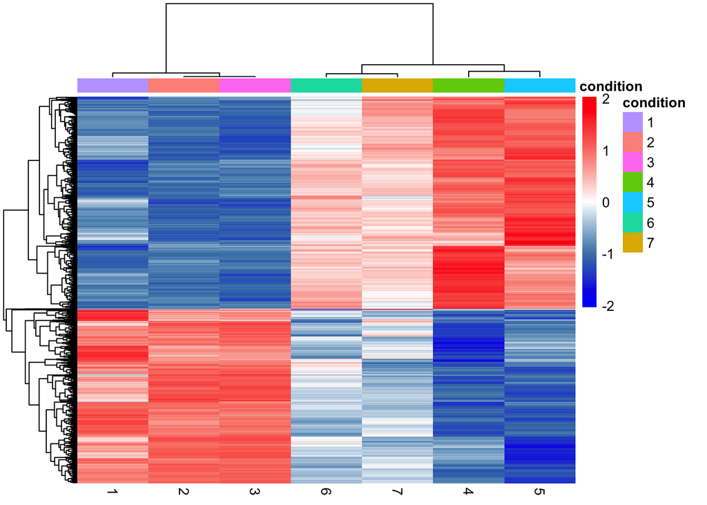

```r
#pdf(file = "SE60_KO_Heatmap_1SV_All_Sig_Genes_pvalue0.0005.pdf",   # The directory you want to save the file in
#    width = 8, # The width of the plot in inches
#    height = 8) # The height of the plot in inches



logcts<- assay(correctedse)

rv <- rowVars(logcts)
o <- order(rv, decreasing=TRUE)[1:3000]
qlfvals<- assay(correctedse)

dists <- Dist(t(qlfvals[o,]), method = 'pearson')
cols <- colorRampPalette(c("blue","steelblue","white",'salmon',"red"))(255)
distmat <- as.matrix(dists)
df <- data.frame(condition=colnames(qlfvals[o,]),
                 row.names=colnames(distmat))
pheatmap(na.omit(qlfvals[o,]),scale = 'row',
         color = cols,
         #clustering_distance_rows= ,
         clustering_distance_cols=dists,
         annotation_col=df,
         show_rownames=FALSE, show_colnames=TRUE)
```

```r
#dev.off()
```

# Comparison

While both the model that includes batch in the design and the model that accounts for batch using SVA seem to perform much better than the base model; the SVA model cleary adjusts for the technical variation between these samples the best. In both cases (Version A and C) PC1 now seperates WT from KO samples, but the degree of this seperation is larger in the SVA model (Version C); in addition looking at the most variable features in the heatmap shows a much cleaner and biologically relevant resolution after using 1 SV to account for technical variation.

# saving output

```r
#ofile <- gzfile("SE60_KO_Results_ANYfc_.0005fdr_SVA1model.txt.gz", open="w")
#write.table(as.data.frame(resSig), file=ofile,
#            row.names=TRUE, quote=FALSE, sep="\t")
#close(ofile)
```

# saving output

```r
#ofile <- gzfile("SE14_KO_ALLRES.txt", open="w")
#write.table(as.data.frame(res), file=ofile,
#            row.names=TRUE, quote=FALSE, sep="\t")
#close(ofile)
```

# Pathway Analysis (MolSigDB)

```r
library(pheatmap)
library(amap)
library(clusterProfiler)
library(DOSE)
library(org.Hs.eg.db)
library(enrichplot)
library(sigclust)
```

This is where I create the background universe of genes (all genes included in the DESEQ2 analyis) as well as read in my data set of significance (all genes at FDR 0.0005) called Screendt in this example as it is the set of genes I want to screen for pathways.

```r
background_universeOG<- x.sub
background_universe<- rownames(background_universeOG)
backgroundgenelist<-bitr(background_universe, fromType='SYMBOL', toType='ENTREZID', OrgDb='org.Hs.eg.db', drop = TRUE)
#backgroundgenelist<-unique(backgroundallset$)
#SE14
Screendt<- read.csv('SE14_CRISPRKO_FDR0.0005_Geneset_DESEQ_data.txt', sep='\t')
#SE60
#Screendt<- read.csv('SE60_CRISPRKO_FDR0.0005_Geneset_DESEQ_data.txt', sep='\t')
LFCs<- Screendt$log2FoldChange
genelist<- rownames(Screendt)


entrezgenelist<-bitr(genelist, fromType='SYMBOL', toType='ENTREZID', OrgDb='org.Hs.eg.db', drop = TRUE)
entrezgenelist<-entrezgenelist[entrezgenelist$SYMBOL %in% rownames(Screendt),]
entrezonly<- entrezgenelist$ENTREZID
```

Then I load the "Hallmark" Gene set from MsigDB

```r
#h.all.v7.4.entrez.gmt  is hallmark
hall<- read.gmt('~/Documents/MOLSIGDB_PATHWAY_Folders/h.all.v7.4.entrez.gmt')
egmt <- enricher(entrezonly, TERM2GENE=hall)
head(egmt)
```

[output not shown]

```r
egmt$Description
```

```
## [1] "HALLMARK_EPITHELIAL_MESENCHYMAL_TRANSITION"
## [2] "HALLMARK_UV_RESPONSE_DN"
## [3] "HALLMARK_TNFA_SIGNALING_VIA_NFKB"
## [4] "HALLMARK_ESTROGEN_RESPONSE_EARLY"
## [5] "HALLMARK_HYPOXIA"
## [6] "HALLMARK_KRAS_SIGNALING_UP"
## [7] "HALLMARK_IL2_STAT5_SIGNALING"
## [8] "HALLMARK_INFLAMMATORY_RESPONSE"
```

Then I can split my gene list into up and down genes, for SE14 the top 100 genes is around -3.5 LFC

```r
#down genes
dwngens<-Screendt[Screendt$log2FoldChange < -3.5,]
dwnentrez<-entrezgenelist$ENTREZID[entrezgenelist$SYMBOL %in% rownames(dwngens)]
egmt <- enricher(dwnentrez, TERM2GENE=hall)
head(egmt)
```

```
##                                                                                    ID
## HALLMARK_EPITHELIAL_MESENCHYMAL_TRANSITION HALLMARK_EPITHELIAL_MESENCHYMAL_TRANSITION
##                                                                           Description
## HALLMARK_EPITHELIAL_MESENCHYMAL_TRANSITION HALLMARK_EPITHELIAL_MESENCHYMAL_TRANSITION
##                                            GeneRatio  BgRatio       pvalue
## HALLMARK_EPITHELIAL_MESENCHYMAL_TRANSITION      8/34 200/4383 0.0001063908
##                                               p.adjust      qvalue
## HALLMARK_EPITHELIAL_MESENCHYMAL_TRANSITION 0.002978943 0.002463788
##                                                                               geneID
## HALLMARK_EPITHELIAL_MESENCHYMAL_TRANSITION 2697/4313/4312/7052/4837/5744/10631/26585
##                                            Count
## HALLMARK_EPITHELIAL_MESENCHYMAL_TRANSITION     8
```

```r
egmt$Description
```

```
## [1] "HALLMARK_EPITHELIAL_MESENCHYMAL_TRANSITION"
```

I can also look at upregulated genes using this same method

```r
#upregulated genes
upgens<-Screendt[Screendt$log2FoldChange > .5,]
upgensenrz<-entrezgenelist$ENTREZID[entrezgenelist$SYMBOL %in% rownames(upgens)]
egmt <- enricher(upgensenrz, TERM2GENE=hall)
head(egmt)
```

```
##                                                                                    ID
## HALLMARK_EPITHELIAL_MESENCHYMAL_TRANSITION HALLMARK_EPITHELIAL_MESENCHYMAL_TRANSITION
## HALLMARK_NOTCH_SIGNALING                                     HALLMARK_NOTCH_SIGNALING
##                                                                           Description
## HALLMARK_EPITHELIAL_MESENCHYMAL_TRANSITION HALLMARK_EPITHELIAL_MESENCHYMAL_TRANSITION
## HALLMARK_NOTCH_SIGNALING                                     HALLMARK_NOTCH_SIGNALING
##                                            GeneRatio  BgRatio       pvalue
## HALLMARK_EPITHELIAL_MESENCHYMAL_TRANSITION    17/156 200/4383 0.0006434951
## HALLMARK_NOTCH_SIGNALING                       6/156  32/4383 0.0007760725
##                                              p.adjust     qvalue
## HALLMARK_EPITHELIAL_MESENCHYMAL_TRANSITION 0.01862574 0.01797221
## HALLMARK_NOTCH_SIGNALING                   0.01862574 0.01797221
##                                                                                                                           geneID
## HALLMARK_EPITHELIAL_MESENCHYMAL_TRANSITION 6695/7431/10398/5999/9353/1000/960/5645/3371/2331/1301/22795/4016/6876/2619/1462/3690
## HALLMARK_NOTCH_SIGNALING                                                                          8324/84441/5578/10402/5467/182
##                                            Count
## HALLMARK_EPITHELIAL_MESENCHYMAL_TRANSITION    17
## HALLMARK_NOTCH_SIGNALING                       6
```

```r
egmt$Description
```

```
## [1] "HALLMARK_EPITHELIAL_MESENCHYMAL_TRANSITION"
## [2] "HALLMARK_NOTCH_SIGNALING"
```

I can make a plot of all significant terms

```r
egmt <- enricher(dwnentrez, TERM2GENE=hall)
head(egmt)
```

```
##                                                                                    ID
## HALLMARK_EPITHELIAL_MESENCHYMAL_TRANSITION HALLMARK_EPITHELIAL_MESENCHYMAL_TRANSITION
##                                                                           Description
## HALLMARK_EPITHELIAL_MESENCHYMAL_TRANSITION HALLMARK_EPITHELIAL_MESENCHYMAL_TRANSITION
##                                            GeneRatio  BgRatio       pvalue
## HALLMARK_EPITHELIAL_MESENCHYMAL_TRANSITION      8/34 200/4383 0.0001063908
##                                               p.adjust      qvalue
## HALLMARK_EPITHELIAL_MESENCHYMAL_TRANSITION 0.002978943 0.002463788
##                                                                               geneID
## HALLMARK_EPITHELIAL_MESENCHYMAL_TRANSITION 2697/4313/4312/7052/4837/5744/10631/26585
##                                            Count
## HALLMARK_EPITHELIAL_MESENCHYMAL_TRANSITION     8
```

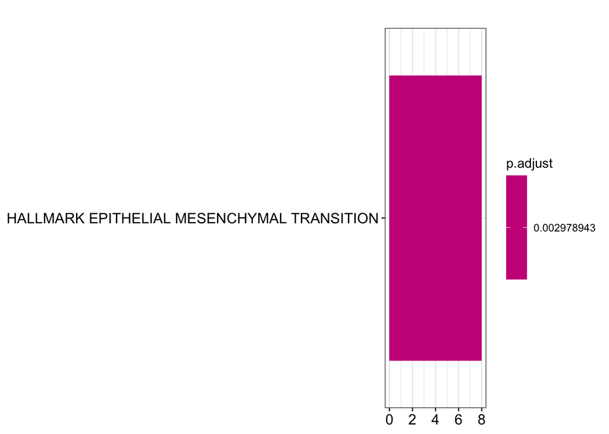

```r
barplot(egmt, showCategory=20)
```

```r
egmt <- enricher(upgensenrz, TERM2GENE=hall)
head(egmt)
```

```
##                                                                                    ID
## HALLMARK_EPITHELIAL_MESENCHYMAL_TRANSITION HALLMARK_EPITHELIAL_MESENCHYMAL_TRANSITION
## HALLMARK_NOTCH_SIGNALING                                     HALLMARK_NOTCH_SIGNALING
##                                                                           Description
## HALLMARK_EPITHELIAL_MESENCHYMAL_TRANSITION HALLMARK_EPITHELIAL_MESENCHYMAL_TRANSITION
## HALLMARK_NOTCH_SIGNALING                                     HALLMARK_NOTCH_SIGNALING
##                                            GeneRatio  BgRatio       pvalue
## HALLMARK_EPITHELIAL_MESENCHYMAL_TRANSITION    17/156 200/4383 0.0006434951
## HALLMARK_NOTCH_SIGNALING                       6/156  32/4383 0.0007760725
##                                              p.adjust     qvalue
## HALLMARK_EPITHELIAL_MESENCHYMAL_TRANSITION 0.01862574 0.01797221
## HALLMARK_NOTCH_SIGNALING                   0.01862574 0.01797221
##                                                                                                                           geneID
## HALLMARK_EPITHELIAL_MESENCHYMAL_TRANSITION 6695/7431/10398/5999/9353/1000/960/5645/3371/2331/1301/22795/4016/6876/2619/1462/3690
## HALLMARK_NOTCH_SIGNALING                                                                          8324/84441/5578/10402/5467/182
##                                            Count
## HALLMARK_EPITHELIAL_MESENCHYMAL_TRANSITION    17
## HALLMARK_NOTCH_SIGNALING                       6
```

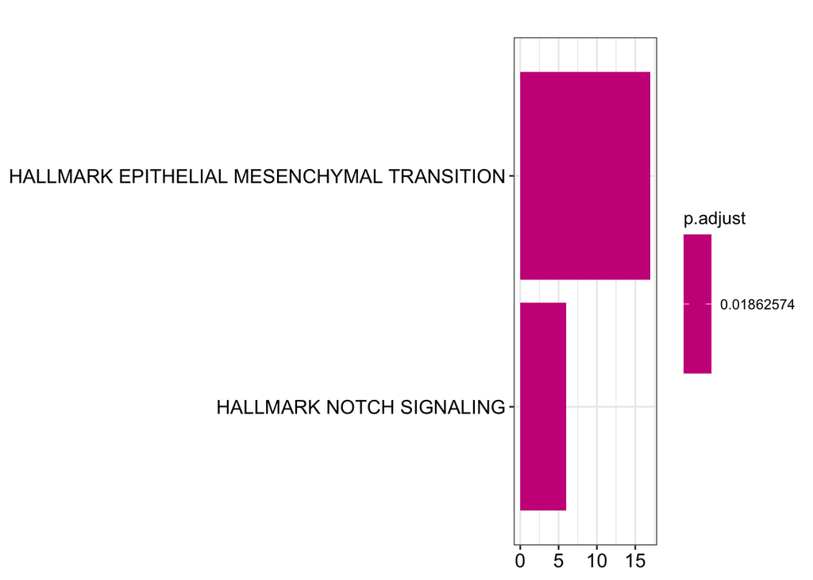

```r
barplot(egmt, showCategory=20)
```

This looks at GO term enrichment

```r
ego <- enrichGO(gene          = dwnentrez,
                universe      = names(entrezonly),
                OrgDb         = org.Hs.eg.db,
                ont           = "MF",
                pAdjustMethod = "BH",
                pvalueCutoff  = 0.05,
                qvalueCutoff  = 0.05,
                readable      = TRUE)
head(ego)
```

```
##                    ID                           Description GeneRatio   BgRatio
## GO:0048018 GO:0048018              receptor ligand activity     12/78 487/18352
## GO:0030546 GO:0030546 signaling receptor activator activity     12/78 492/18352
## GO:0005125 GO:0005125                     cytokine activity      6/78 235/18352
##                  pvalue     p.adjust       qvalue
## GO:0048018 9.440793e-07 0.0001360806 0.0001128244
## GO:0030546 1.050816e-06 0.0001360806 0.0001128244
## GO:0005125 4.924122e-04 0.0425115904 0.0352463501
##                                                                       geneID
## GO:0048018 FLRT2/CD70/IL18/PTN/WNT10A/CALCB/CALCA/WNT7A/PTHLH/STC1/TNF/GREM1
## GO:0030546 FLRT2/CD70/IL18/PTN/WNT10A/CALCB/CALCA/WNT7A/PTHLH/STC1/TNF/GREM1
## GO:0005125                                  CD70/IL18/WNT10A/WNT7A/TNF/GREM1
##            Count
## GO:0048018    12
## GO:0030546    12
## GO:0005125     6
```